# What Do Inauguration Speeches Tell Us?

[figure not shown]

Inauguration speech, known as the first official speech that the new US President will give to the world, shows that how the President and his team will lead the country and how this country will develop in the next four years. More or less, the inauguration speech also illustrates the character of the President and his attitude towards this special position. What these Presidents have said reflects what points has this country focused on and what problems has this country been faced. Therefore, it is interesting and meaningful to analyze the differences among these inauguration speeches.

### Did Trump do well in the Inauguration Speech?

|  | Number of Sentences | Average Words Per Sentence | Total Words | Total Vocabulary |
| --- | --- | --- | --- | --- |
| average | 108 | 26 | 2623 | 890 |
| Donald J. Trump | 95 | 15 | 1453 | 579 |
| Barack Obama | 123 | 19 | 2395 | 935 |
| George W. Bush | 102 | 16 | 1590 | 628 |
| William J. Clinton | 102 | 16 | 1598 | 634 |
| George Bush | 166 | 14 | 2312 | 795 |
| Ronald Reagan | 138 | 17 | 2427 | 901 |
| Jimmy Carter | 61 | 20 | 1213 | 523 |
| Richard Nixon | 120 | 18 | 2103 | 756 |
| Lyndon B. Johnson | 97 | 15 | 1496 | 580 |

[output cut: 30 more lines]

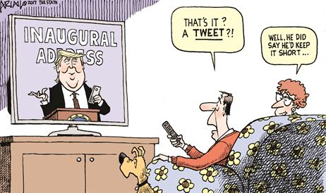

One of the possible reasons is that President Trump wants to show citizens a different personal style compared with those Presidents known as famous politicians. Actually, this is one of the reasons why he could get such a huge amount of supporters. From the inauguration speech, he has already started his plan making some changes in this country. Or maybe just as he said he didn’t want people standing out in the cold for a long time.

To visualize how inauguration speeches changed over time, I made following four plots.

### Let’s focus on how inauguration speeches have changed

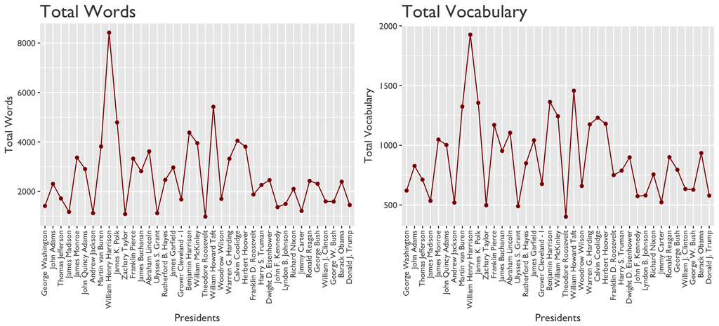

As time goes on, in inauguration speech, the total words and total vacabulary have not changed a lot and this value has turned to be stable in recent several decades. From the figure, we can see that in early days, it was usual that the total words of one year was much more or less than the next year or the previous year. But nowadays, this number has been stabilized to be around 2000. This is because the inauguration speech has played a more and more important role these years. Presidents use it to show his plan and power in the next few years. The best way making a speech serious and formal is to standardize the speech in terms of the length and expression. Thus, the total words have been controlled.

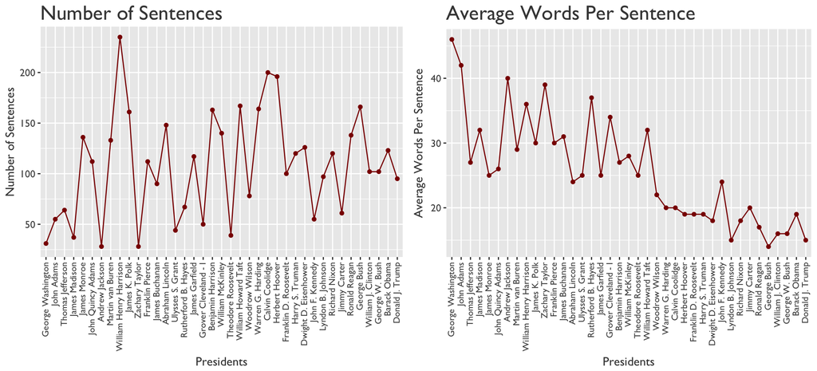

However, if looking at the number of sentences and the average words per sentence, we can find that there is a uptrend for number of sentences and an obvious descend trend for the average words per sentence, which means Presidents started to shorten their sentences. That might because the pace of life turning more and more quick, people have already got used to reading short sentences posted on all kinds of social Apps rather than reading newspapers and long sentences. Indeed, shorter sentences are much more acceptable for people. As a result, Presidents started to talk to all of us by shortening their sentences.

If combining these four figures, we should notice that not the length of the speech but the pace of the speech is changing.

### What words did Presidents say?

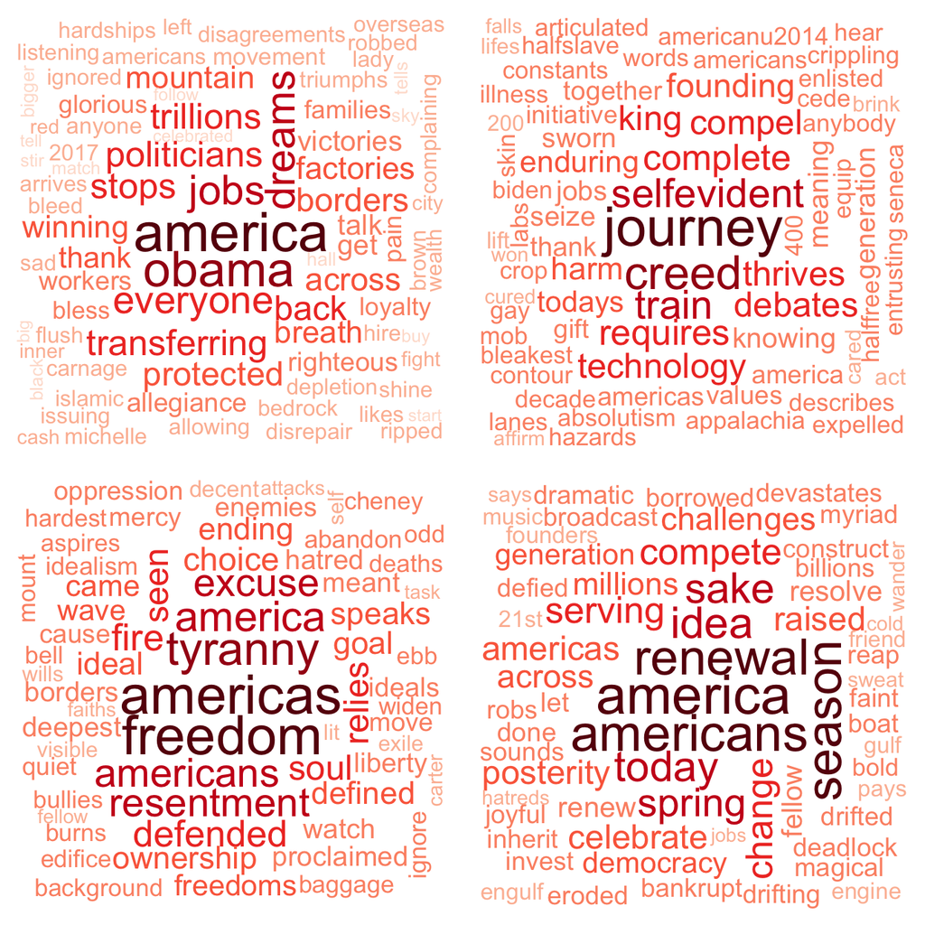

The word cloud technology shows us what does a President say much during the speech. First, President Clinton, who won the competition against George Bush. As a young politician at that time, he focused on economic revolution. So in his inauguration speech, we can see words like renewal, today, raise, and so on.

As for President George W Bush, just like his father, he focused more on safety problems inside and outside the country. During his term of office, US army invaded Iraq and Afghan. In his inauguration speech, we see tyranny, fire, defend, etc.

Finally, President Trump had been focusing on solving the employment problem and protecting domestic workers before he won the presidential election. So during his inauguration speech, we see words like jobs, dreams, everyone factories, protected, etc.

What’s more, I find that three of recent four presidents loved to say “America” in their inauguration speech, especially President Trump, he hit the world for 35 times. So I made a plot to see if there is any trend.

### Count the number of “America” in inauguration speeches

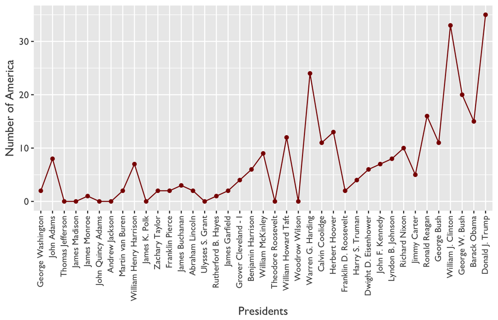

### Sentiment Analysis of Inauguration speeches

Finally, in the sentiment analysis part, whether the sentiment was positive or negative during the whole speech process has been showed in the following figures. Red parts mean positive and blue parts mean negative.

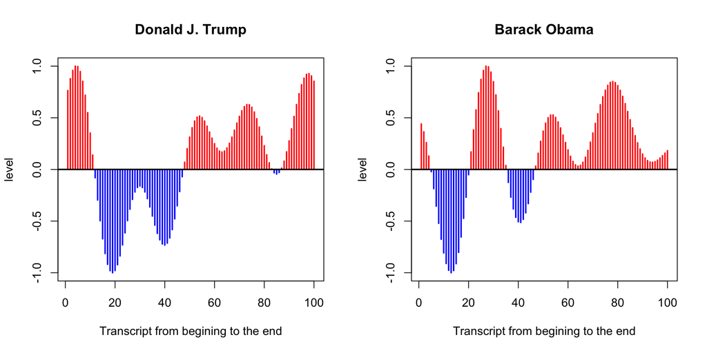

[figure not shown]

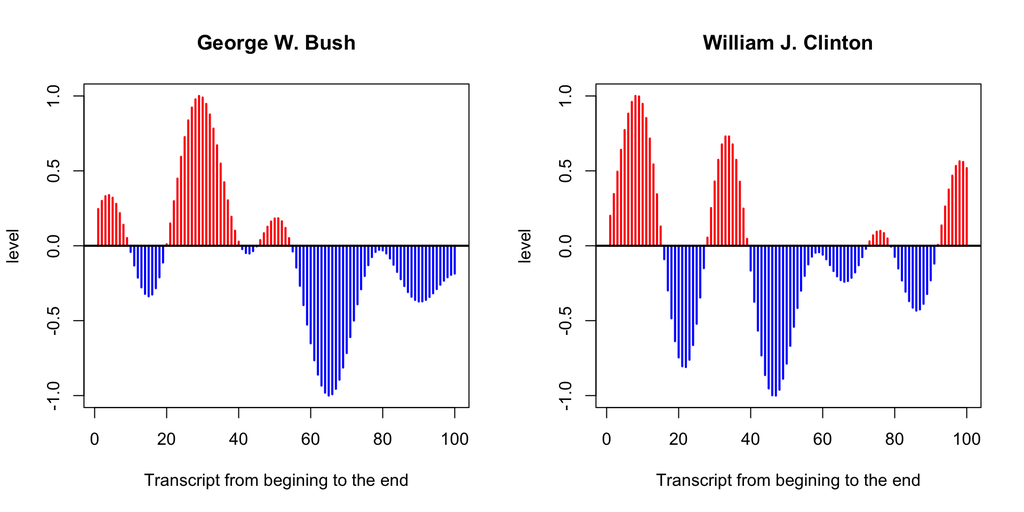

To sum up, the sentiment analysis can somehow demonstrates the President’s attitude towards the future of this country.